# R, RStudio, and the console · vectors · types

Tuesday, May 19, 2026

**NoteToday: Tuesday May 19**

**Before class**

- **First Perusall Assignment**: *Data Computing* §2.1-2.8 ([Click here](https://psu.instructure.com/courses/2487468/assignments/18307706)).

**Plan for today**

- Tour of RStudio
- Using R as a calculator
- Data types and vectors
- Creating objects

**Helpful links**

- Syllabus · AI policy · Schedule · [*Data Computing* §2](https://dtkaplan.github.io/DataComputingEbook/chap-computing-with-r.html#chap:computing-with-r)

## What is Computing?

Computing is about turning human ideas into reproducible instructions that a computer can carry out.

In this course, we will learn how to:

- organize data
- automate calculations
- visualize information
- build reproducible analyses
- communicate results

R is the tool we will use to do that.

## Another Introduction to R

- R is a programming language designed for data analysis, statistics, and visualization.
- We use R to tell the computer exactly what computations we want to perform.
- R is widely used in:
  - statistics
  - data science
  - research
  - industry analytics
- R is free, open-source, and highly extensible through thousands of packages that contain additional tools and functions.

## RStudio Desktop (RStudio)

- First version released in 2011.
- *Integrated development environment (IDE)* provides additional tools and window management to R to help coders, statisticians, and data scientists use R more effectively.
- While R is required to run RStudio, you do not need to have RStudio to use R.

## R vs. RStudio

- **R** is the programming language.
- **RStudio** is the environment/interface we use to work with R more comfortably.

# A tour of RStudio

## RStudio’s Four Pane Layout

[figure not shown]

RStudio’s four pane layout.

## Source Pane

[figure not shown]

RStudio’s source pane, annotated.

## Console Pane

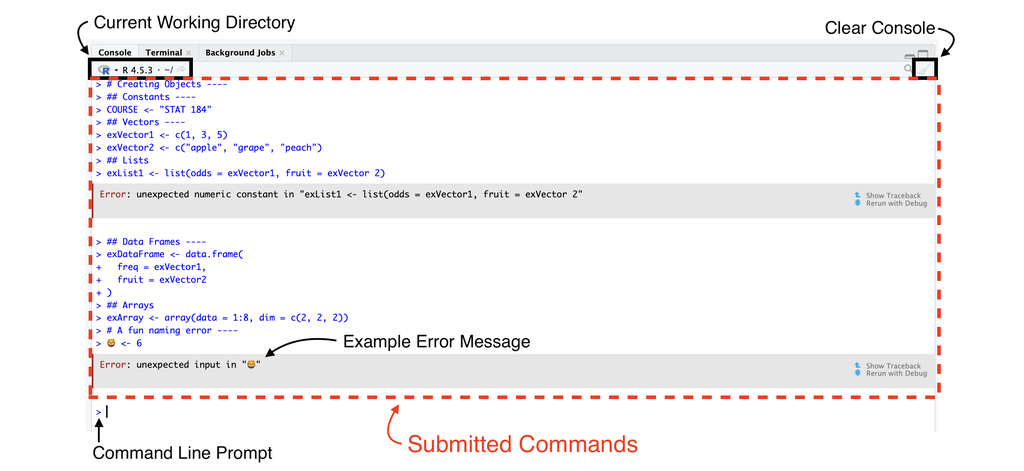

RStudio’s console, annotated.

## Environment Pane

[figure not shown]

RStudio’s environment pane, annotated.

## Output Pane - Files Tab

[figure not shown]

RStudio’s output pane (files tab), annotated.

## Output Pane - Plots Tab

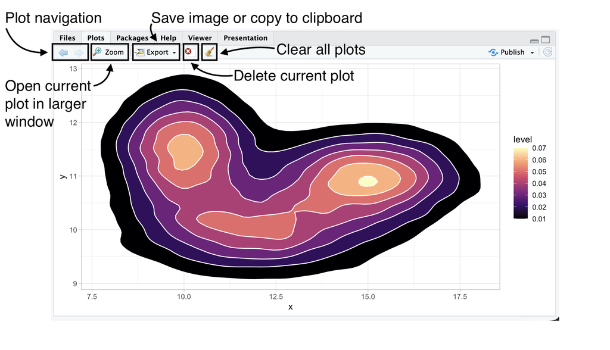

RStudio’s output pane (plots tab), annotated, displaying a 2D density contour plot created with ggplot2.

**Show the R code.**

```r
# Set Seed
set.seed(184)

# Library
library(tidyverse)

# Data
a <- data.frame(x = rnorm(20000, 12,   2),   y = rnorm(20000, 10,   0.5))
b <- data.frame(x = rnorm(20000, 15,   1.5), y = rnorm(20000, 11,   0.5))
c <- data.frame(x = rnorm(20000, 10,   1.1), y = rnorm(20000, 11.5, 0.7))
data <- rbind(a, b, c)

# Area + contour
ggplot(data, aes(x = x, y = y)) +
  stat_density_2d(aes(fill = after_stat(level)),
                  geom = "polygon", colour = "white") +
  theme_light() +
  scale_fill_viridis_c(option = "magma")
```

## Output Pane - Packages Tab

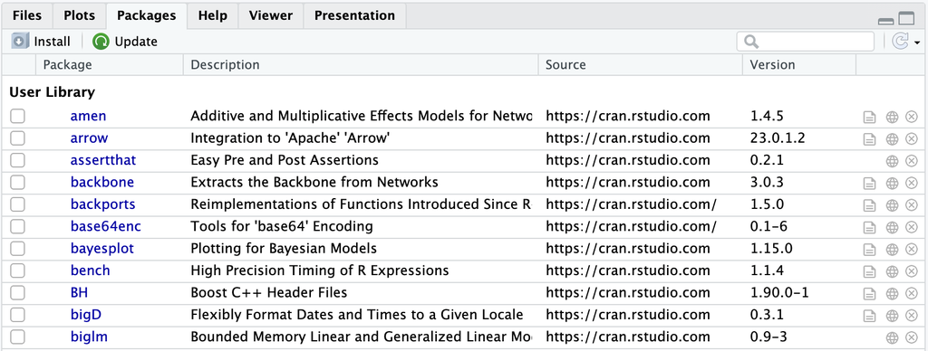

RStudio’s output pane (packages tab).

- The “Packages” tab will list all packages that you have currently installed on your machine. You can load a package by clicking the box to the left of the name.
- You can also use the “Install” and “Update” buttons to help you get new packages and keep them current.

## Output Pane - Help Tab

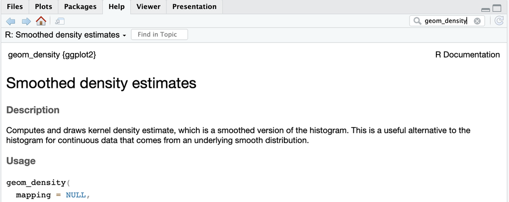

RStudio’s output pane (help tab).

- The “Help” tab displays help documentation that has been included with the packages for functions, data sets, and other objects.
- **Help Shortcuts:** `?barplot`, `help(barplot)`, or `??barplot` (broad sweep). You can also place your cursor in the object name and press fn + F1 (or just F1 if your function keys are active).

# Data types and structures

## Data Types

- Data type refers to the nature of how we choose to record some value.
- **Common Data Types in R:**
  - Numeric (Double)
  - Integer
  - Complex
  - Character
  - Logical

## Data Structures

- Data structures are the most important type of base objects in R as they will form the basis for all manipulations we do.
- R’s data structures may be organized along two aspects:
  1. How many dimensions we need for values.
  2. If all values have to be the same data type.

Table 1: Summary of R’s main base data structures by dimension and type-mixing.

| Structure | Dimensions | Mixed types? |
| --- | --- | --- |
| Vector | 1 | No |
| List | 1 | Yes |
| Matrix | 2 | No |
| Data frame | 2 | Yes (across columns) |
| Array | n ($\geq$ 2) | No |

## Data Structures Examples

Table 2: Examples of each data structure showing its printed form in the R console.

Dimensions

All Values Same Data Type

A Mix of Data Types

**1 Dimension**

**Atomic Vectors**

```
[1] 1 3 5
[1] "apple" "grape"
"peach"
```

**List**

```
[[1]]
[1] 1 3 5

[[2]]
[1] "apple" "grape"
"peach"
```

**2 Dimensions**

**Matrix**

```
     [,1] [,2]
[1,]    1    5
[2,]    3    7
```

**Data Frame**

```
  id  fruit
1  1  apple
2  3  grape
3  5  peach
```

**n Dimensions**

**Array**

[output not shown]

*Not applicable*

## Data Structures Visualization

**Show the R code.**

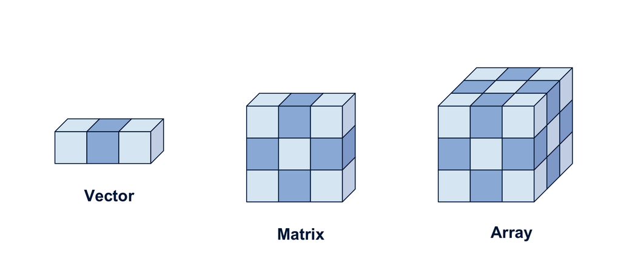

Figure 1: R’s data structures as cubes: a vector (1D), matrix (2D), and array (3D).

```r
# Color palette
bg_color    <- "#FFFFFF"
light_blue  <- "#DDEAF5"
mid_blue    <- "#9BB8DC"
edge_color  <- "#001E44"   # Penn State Navy

# Draw a single unit cube at grid position (gx, gy, gz)
# Uses simple axonometric projection: x' = gx + 0.4*gz, y' = gy + 0.4*gz
draw_cube <- function(gx, gy, gz, fill = light_blue) {
  s  <- 1
  dx <- 0.4 * s
  dy <- 0.4 * s

  px <- gx + dx * gz
  py <- gy + dy * gz

  # Front face
  polygon(c(px, px + s, px + s, px),
          c(py, py,     py + s, py + s),
          col = fill, border = edge_color, lwd = 1.2)
  # Top face
  polygon(c(px,        px + s,        px + s + dx, px + dx),
          c(py + s,    py + s,        py + s + dy, py + s + dy),
          col = fill, border = edge_color, lwd = 1.2)
  # Right face (slightly darker for shading)
  shade <- adjustcolor(fill, red.f = 0.92, green.f = 0.92, blue.f = 0.95)
  polygon(c(px + s,    px + s + dx,   px + s + dx, px + s),
          c(py,        py + dy,       py + s + dy, py + s),
          col = shade, border = edge_color, lwd = 1.2)
}

# Alternating fill in 3D (checkerboard)
checker_fill <- function(i, j, k = 0) {
  if ((i + j + k) %% 2 == 0) light_blue else mid_blue
}

par(mar = c(0, 0, 0, 0), bg = bg_color)
plot.new()
plot.window(xlim = c(0, 18), ylim = c(0, 6), asp = 1)

# 1. Vector: 1 x 3 row
ox <- 1; oy <- 2.2
for (i in 0:2) {
  draw_cube(ox + i, oy, 0, fill = checker_fill(i, 0))
}
text(ox + 1.7, oy - 1, "Vector",
     cex = 1.4, col = edge_color, font = 2)

# 2. Matrix: 3 x 3 grid
ox <- 7; oy <- 1
for (j in 0:2) {
  for (i in 0:2) {
    draw_cube(ox + i, oy + j, 0, fill = checker_fill(i, j))
  }
}
text(ox + 1.7, oy - 1, "Matrix",
     cex = 1.4, col = edge_color, font = 2)

# 3. Array: 3 x 3 x 3 cube — draw back-to-front, bottom-up, left-right
ox <- 13; oy <- 1
for (k in 2:0) {
  for (j in 0:2) {
    for (i in 0:2) {
      draw_cube(ox + i, oy + j, k, fill = checker_fill(i, j, k))
    }
  }
}
text(ox + 2.3, oy - 1, "Array",
     cex = 1.4, col = edge_color, font = 2)
```

# R as a calculator · creating objects

## R as a Calculator

You can use R as a calculator:

```r
184.101 * 9.35
```

```
[1] 1721.344
```

```r
(8 + 4) / 9
```

```
[1] 1.333333
```

```r
sqrt(8)
```

```
[1] 2.828427
```

```r
cos(2 * pi)
```

```
[1] 1
```

## Your Turn to Use the Calculator

Your turn. Open the console and try each line below; don’t just read them, **type them**.

```r
2 + 2

sqrt(16)

c(1, 2, 3) * 2

10 %% 3

x <- log(10^2, base = 10)
x
```

## Vector Operations

```r
c(1, 8, 4) + c(9, 3, 5)
```

```
[1] 10 11  9
```

```r
c(1, 8, 4) * c(9, 3, 5)
```

```
[1]  9 24 20
```

- The `c()` function **concatenates** multiple individual values into one single vector.

## Built-in Functions and Constants

```r
exp(1)
```

```
[1] 2.718282
```

```r
sqrt(pi)
```

```
[1] 1.772454
```

```r
dnorm(0)
```

```
[1] 0.3989423
```

- `sqrt` computes the square root.
- `exp` computes the function $e^x$.
- `pi` is the constant $\pi$.
- `dnorm` computes the standard normal density function.

## Creating objects

You can create new objects with the **assignment operator**, `<-`:

```r
x <- 3 * 5
```

The above is an example of an **assignment statement**. In general, assignment statements have the form:

```r
object_name <- value
```

In English, this is “object_name **gets** value.”

- Even though typing `<-` for the many assignments you will make can be tedious, **don’t use `=`**; it will work, but will cause confusion later.
- You can use the RStudio keyboard shortcut `Alt` + `-` (or `Option` + `-` on a Mac).
- Object names must start with a letter, and can only contain letters, numbers, `_`, and `.`

## Setup checklist — due by Wednesday

**Install R and RStudio**

- R: https://cloud.r-project.org
- RStudio: https://posit.co/download/rstudio-desktop

**WarningMac users**

Install [**XQuartz**](https://www.xquartz.org) too — some packages we’ll use later in the course need it.

**Configure RStudio**

- `Tools > Global Options... > General`
- Restore .RData into workspace at startup: **Unchecked**
- Save workspace to .RData on exit: **Never**

## Wrap-up & looking ahead

**Tomorrow:** Functions, packages, the tidyverse, and objects.

**Upcoming Deadlines**

- **Wed 5/20, before class** — [DC §3.1–3.5](https://psu.instructure.com/courses/2487468/assignments/18307709)
- **Wed 5/20, 11:59 p.m.** — [HW 0: Setup](https://psu.instructure.com/courses/2487468/assignments/18308171)
- **Fri 5/22, in class** — Quiz 1
- **Fri 5/22, 11:59 p.m.** — [HW 1: Basic R & Plots](https://psu.instructure.com/courses/2487468/assignments/18311694)

**Reach out**

Stuck? Office hours, or email me (cgc5478@psu.edu) or Xinyue (xpw5228@psu.edu).

**Reference**

Syllabus · AI policy · Schedule · [*Data Computing*](https://dtkaplan.github.io/DataComputingEbook/)